# Dosage data and analyses brief

This document shows the descriptive statistics and potential analyses of the dosage paper.

Author

Affiliation

Emiel Schoneveld

University of Amsterdam

Published

June 17, 2026

# 1 Mediation analysis

## 1.1 Model description

This model is used to investigate whether the wordreading improvements are caused by the number of words students read and/or the amount of time they have practiced. Words exposures is defined ass the number of times a students was presented with a word. The model displayed below was fitted with and without the direct effect of time on post.

**Note**

The covariances are omitted in the figure for legibility.

[interactive chart not shown]

## 1.2 Results

The models were fitted for three outcome measures. Below the standardized estimates of the regression parameters and the full vs partial mediation anova test.

**Note**

Greyed out boxes are omitted regression paths because of full mediation

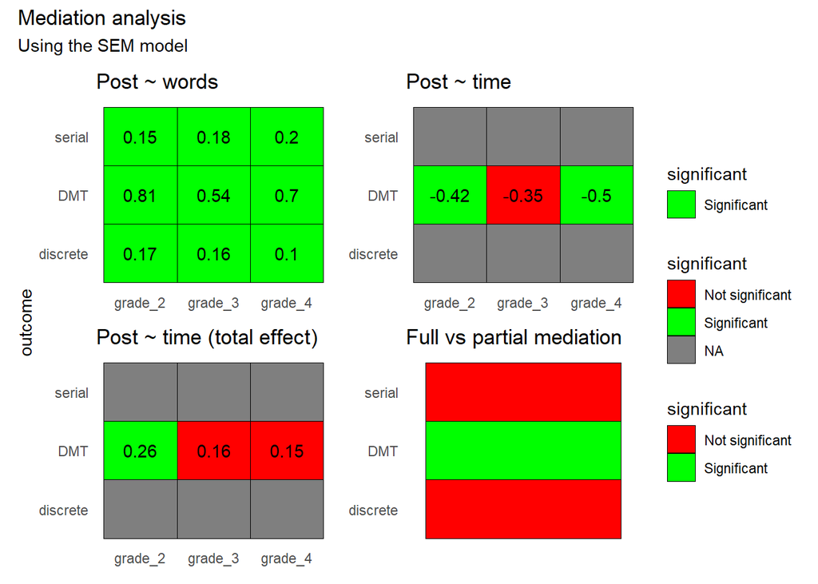

# 2 Interaction analysis

## 2.1 Model description

Using an OLM linear model the following model was fitted to check the influence of accuracy. The effect of time on post was omitted for discrete and serial because it was fully mediated by words_exposures.

[interactive chart not shown]

## 2.2 The results

The models were fitted for three outcome measures. Below the standardized regression estimates.

**Note**

Greyed out boxes are omitted regression paths because of full mediation in the previous analysis.

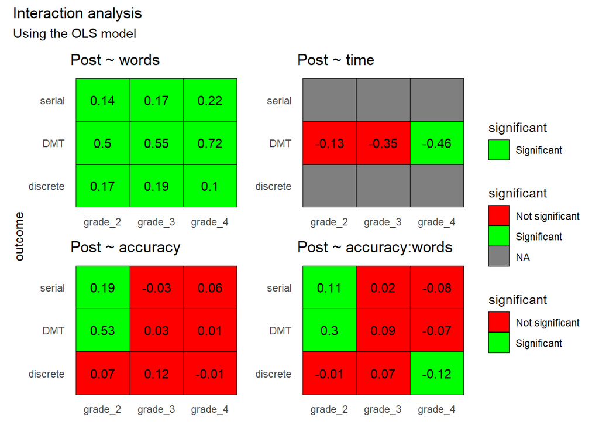